# R Notebook

# graph 1

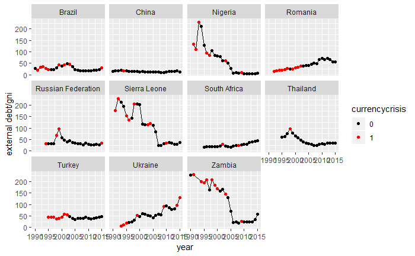

```r
p <- ggplot(df1,aes(year,externaldebtgni))+
  geom_line()+
  geom_point(aes(year,color=currencycrisis))+
  ylab("external debt/gni")+
  scale_color_manual(values=c("black","red"))+
  facet_wrap(~countryx)

p
```

```r
NA
NA
```

# graph 2

multicollinearity: see the relationship between control variable: polity score and gdp per capita

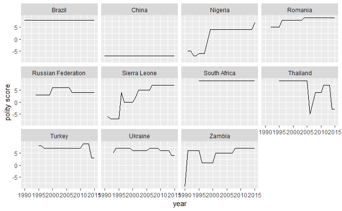

```r
q1 <- ggplot(df1,aes(year,polity2))+
  geom_line()+
  ylab("polity score")+
  facet_wrap(~countryx)
q1
```

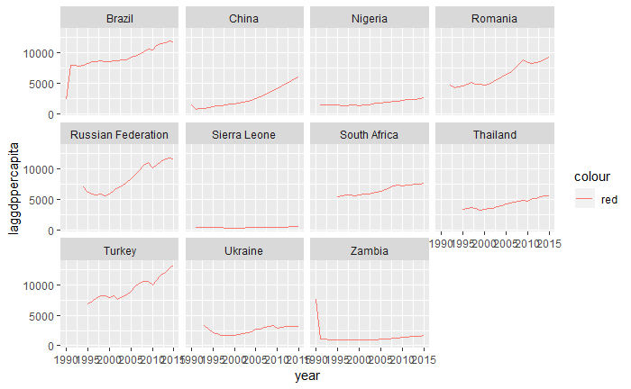

```r
q2 <- ggplot(df1,aes(year,laggdppercapita,color="red"))+
  geom_line()+
  facet_wrap(~countryx)
q2
```

multicolinear? it make sense: Nigeria, Romania -> The more “democratic”, the higher lagged gdp per capita not make sense: China, Brazil,Russia, Ukraine, Sierra Leone, South Africa, Thailand, Turkey #some relationship found

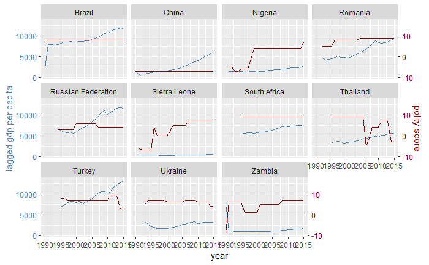

```r
ggplot(df1,aes(x=year))+
  geom_line(aes(year,laggdppercapita),color="steel blue")+
  geom_line(aes(year,(polity2+10)*500),color="dark red")+
  scale_y_continuous(name="lagged gdp per capita", sec.axis=sec_axis(~./500-10, name="polity score"))+
  theme(axis.title.y.left=element_text(color="steel blue"),
    axis.text.y.left=element_text(color="steel blue"),
    axis.title.y.right=element_text(color="dark red"),
    axis.text.y.right=element_text(color="dark red"))+
  facet_wrap(~countryx)
```

# graph 3

external shock

```r
 df2 <- df%>%
  filter(currencycrisis==1)
```

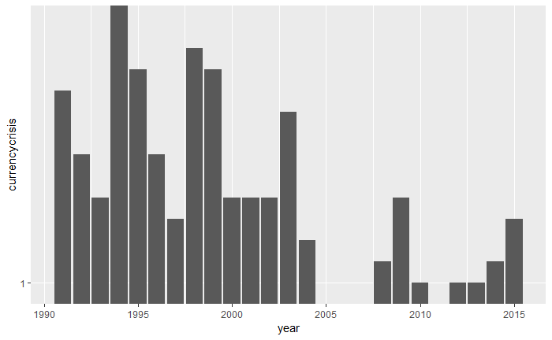

```r
ggplot(df2,aes(x=year))+
geom_bar(mapping = aes(x = year, y = currencycrisis), stat = "identity")
```

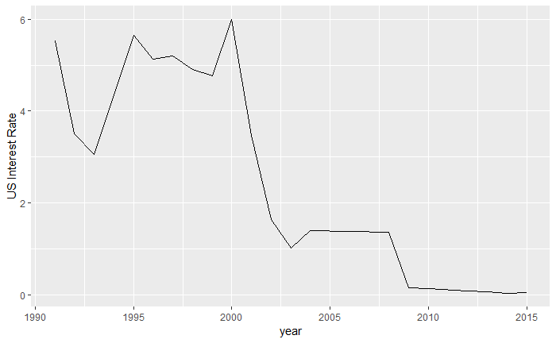

```r
ggplot(df2,aes(x=year))+
  geom_line(aes(year,us3mtreasuryyield))+
  ylab("US Interest Rate")
```

The trends of US interest rate and # of countries undergoing currency crisis appear to move in the same direction approximately. US interest rate as an external shock has an impact on EMEs’ currency crisis. #relationship found

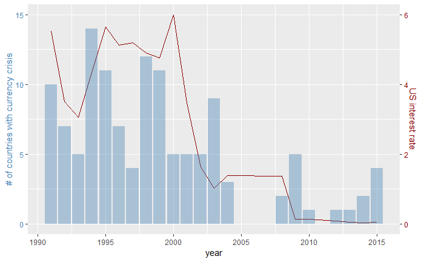

```r
ggplot(df2,aes(x=year))+
  geom_line(aes(year,us3mtreasuryyield*2.5),color="dark red")+
  geom_bar(mapping = aes(x = year, y = currencycrisis), stat = "identity",fill="steel blue",alpha=0.4)+
  scale_y_continuous(name="# of countries with currency crisis", sec.axis=sec_axis(~./2.5, name="US interest rate"))+
  theme(axis.title.y.left=element_text(color="steel blue"),
    axis.text.y.left=element_text(color="steel blue"),
    axis.title.y.right=element_text(color="dark red"),
    axis.text.y.right=element_text(color="dark red"))
```

# graph 4

polity score and currency crisis by country: no direct relationship found

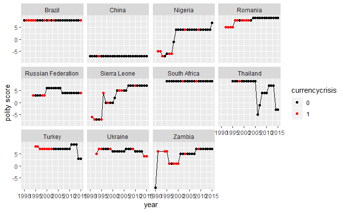

```r
 ggplot(df1,aes(year,polity2))+
  geom_line()+
  geom_point(aes(year,color=currencycrisis))+
  ylab("polity score")+
  scale_color_manual(values=c("black","red"))+
  facet_wrap(~countryx)
```

# graph 5

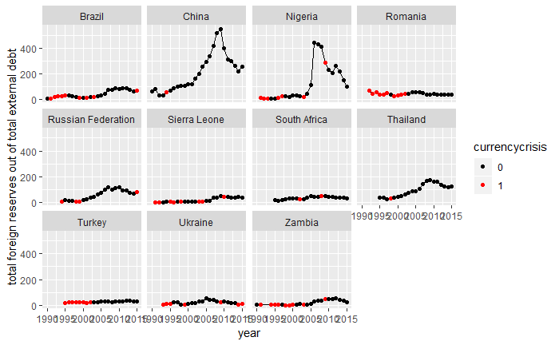

```r
 ggplot(df1,aes(year,totalreservesoutoftotalexternald))+
  geom_line()+
  geom_point(aes(year,color=currencycrisis))+
  ylab("total foreign reserves out of total external debt")+
  scale_color_manual(values=c("black","red"))+
  facet_wrap(~countryx)
```